# Cyclistic Bike-Share Analysis: Converting Casual Riders into Annual Members

Data Analytics Capstone

November 2026

## 1. Ask: Business Task & Executive Summary

Cyclistic’s marketing team wants to maximize the number of annual memberships by converting existing casual riders (single-ride and full-day pass users) into annual subscribers. An analysis of **6.13 million valid rides** from November 2025 through October 2026 reveals clear behavioral differences between the two groups:

- **Ridership Share:** Annual members account for **64.7%** of total rides (3,967,675 trips), while casual riders account for **35.3%** (2,161,947 trips).
- **Trip Duration:** Casual riders average **18.0 minutes per ride**—nearly **50% longer** than annual members (**12.1 minutes**).
- **Usage Patterns:** Members ride consistently on weekdays for commuting, whereas casual riders surge on weekends and during warm summer months for leisure.

## 2. Prepare: Data Sources & Limitations

- **Data Source:** Public historical trip data provided by Motivate International Inc. (Divvy bike-share in Chicago) under the official data license agreement, covering the trailing 12 months from November 2025 through October 2026 (`202511` to `202610`).
- **Data Limitations:** Personally identifiable information (PII) such as rider IDs and credit card details is stripped for privacy, preventing tracking of individual repeat casual riders across multiple trips.

## 3. Process: Data Cleaning & Manipulation

Using R (`tidyverse` and `lubridate`), all 12 monthly datasets were standardized and filtered to remove test/maintenance trips under 1 minute, extreme outliers exceeding 24 hours (1,440 minutes), and null classifications—resulting in **6,129,622 valid rides**. Derived metrics included `ride_length_mins`, `day_of_week`, and `month`.

| Rider Type | Total Rides | Share (%) | Avg Duration (Mins) |
| --- | --- | --- | --- |
| casual | 2,161,947 | 35.3 | 18.0 |
| member | 3,967,675 | 64.7 | 12.1 |

## 4. Analyze: Summary of Analysis

Across the 12-month period, annual members generated **64.7% of total ride volume** (3,967,675 trips) while casual riders generated **35.3%** (2,161,947 trips). Despite taking fewer trips overall, casual riders averaged **18.0 minutes per ride** compared to **12.1 minutes** for annual members—nearly 50% longer per trip. Behavioral segmentation by day of week and month confirms two distinct user profiles: annual members rely on the service for consistent weekday commuting, whereas casual riders primarily use bikes for longer leisure trips on weekends and during peak summer weather.

## 5. Share: Supporting Visualizations & Key Findings

### A. Weekly Ridership Volume: Commuters vs. Weekend Leisure

Annual members peak Tuesday through Thursday, reflecting routine work commutes. Casual riders show the exact opposite pattern, peaking sharply on Saturdays and Sundays.

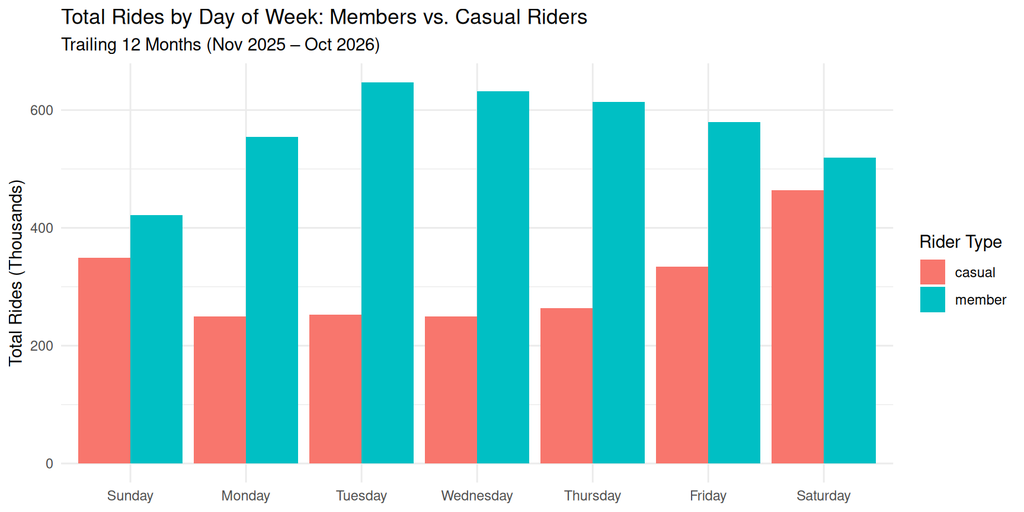

### B. Average Ride Duration by Day of Week

Across every single day of the week, casual riders take significantly longer trips than annual members, peaking on weekends.

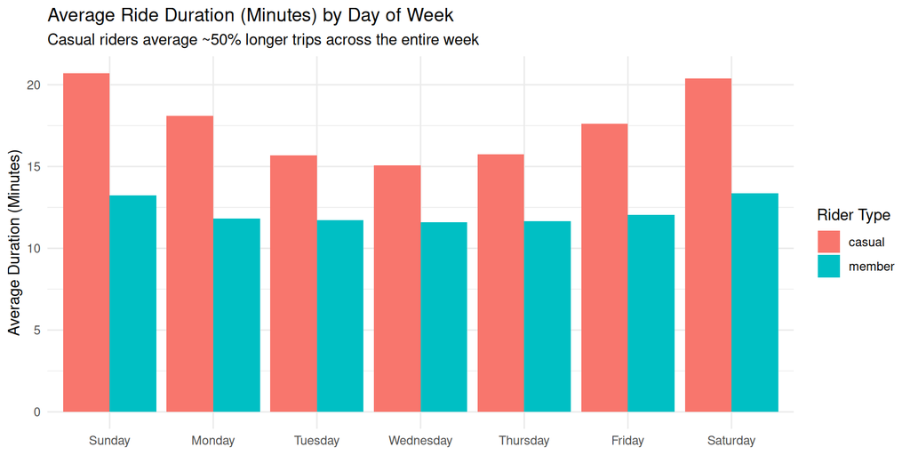

### C. Monthly Seasonality Trends

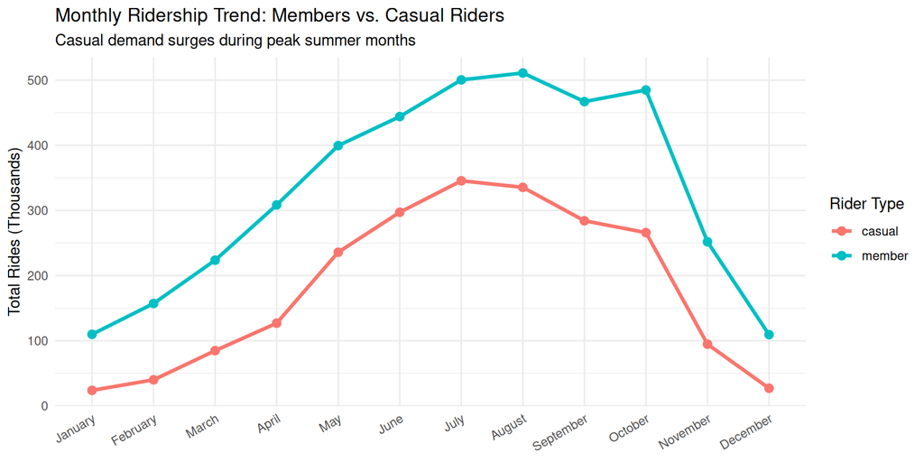

## 6. Act: Top 3 Strategic Recommendations

1. **Introduce a Seasonal / Weekend Leisure Pass**
   - **Target & Tactic:** Launch a lower-barrier “Summer Pass” (May–September) or “Weekend Warrior” subscription tier tailored to recreational riders who peak on Saturdays and Sundays.
   - **Expected Impact:** Captures high-volume summer and weekend casual demand while creating an easy upsell path to full annual membership.
2. **Trigger Automated Post-Ride Cost-Savings Prompts**
   - **Target & Tactic:** Deploy in-app push notifications immediately after a casual rider completes a trip exceeding 15 minutes (below their 18.0-minute average) or takes a second ride within 7 days, displaying exact dollar savings under an annual plan.
   - **Expected Impact:** Converts high-frequency or long-duration casual riders at the exact moment they experience the highest single-ride pricing friction.
3. **Target Weekday Casual Commuters with a 7-Day Free Trial**
   - **Target & Tactic:** Segment casual riders unlocking bikes during peak weekday commute windows (7–9 AM and 4–6 PM) and offer a frictionless 7-day free trial of annual membership perks.
   - **Expected Impact:** Directly converts existing weekday commuters into recurring annual subscribers by letting them experience unlimited commuter unlocks risk-free.